# Pupil Data Quality Report: Data Availability and Analysis Readiness for Chapters 2 & 3

BAP Study - Pupillometry Analysis Pipeline

Author

Mohammad Dastgheib

Published

January 12, 2026 at 04:38 PM

## 1 Executive Summary

### 1.1 What I Need From You

**Decision Points**

Please review and approve the following:

1. **Quality Thresholds**: Review current default thresholds for Chapter 2 (60%) and Chapter 3 (50% + RT filter). Note: Final threshold selection will be determined based on sensitivity analyses in dedicated analysis scripts.
2. **AUC Requirement for Pupil-Enhanced DDM**: Approve whether to require `auc_available == TRUE` for the pupil-predictor DDM subset (see Section 6.2 for intersection counts)
3. **Sensitivity Analysis**: Approve whether to run and report 50% and 70% threshold sensitivity analyses as robustness checks (even if brief)

This report provides a comprehensive overview of the pupil data collected in the BAP (Brain, Aging and Perception) study, with a focus on data quality, availability, and readiness for two dissertation chapters. **This report establishes the foundation (data availability, retention rates, quality metrics) but final threshold recommendations will be determined based on sensitivity analyses conducted in dedicated Chapter 2 and Chapter 3 analysis scripts**, comparing effect sizes, standard errors, and statistical significance across threshold combinations:

- **Chapter 2**: Psychometric sensitivity and pupil-indexed arousal coupling analyses
- **Chapter 3**: Drift Diffusion Model (DDM) analyses with pupil predictors

### 1.2 Key Findings

- **Total Participants**: 63 participants with pupil data
- **Total Trials Available**:
  - Total trials in dataset: 14,586
  - Trials with behavioral data: 12,715 (87.2% behavioral join rate)
  - Trials with both AUC metrics: 50.5% overall
- **Chapter 2 Readiness** (Primary threshold: 60% validity):
  - Usable trials: 4,117 (28.2% of total trials)
  - Analysis-ready dataset: 14,586 trials in `ch2_triallevel.csv` (contains ALL pupil trials; filter by `gate_pupil_primary == TRUE` to get the 4,117 analysis-ready trials)
- **Chapter 3 Readiness** (Primary threshold: 50% validity + behavioral RT filter):
  - Pupil+behavior-ready trials: 5,180 (35.5% of total trials)
  - Analysis-ready dataset: 14,586 trials in `ch3_triallevel.csv` (contains ALL pupil trials; filter by `ddm_ready == TRUE` to get the 5,180 analysis-ready trials)

*Note: Both analysis-ready datasets contain the same 14,586 trials (ALL pupil trials from the merged dataset). They differ only in the quality flags provided (`gate_pupil_primary` for Chapter 2, `ddm_ready` for Chapter 3), allowing us to filter to the trials that meet each chapter’s quality criteria. The datasets include trials both WITH and WITHOUT behavioral data; filter by the quality flags to get the analysis-ready subsets.*

- **AUC Availability** (Both Total AUC and Cognitive AUC):
  - Overall: 50.5%
  - ADT: 47.2%
  - VDT: 54.0%

### 1.3 Data by Task

Data Availability by Task (Chapters 2 & 3)

| Task | Total Trials | Ch2 Ready (60%) | Ch2 % | Ch3 Ready (50%+RT) | Ch3 % | AUC Ready | AUC % |
| --- | --- | --- | --- | --- | --- | --- | --- |
| ADT | 6404 | 1984 | 31.0 | 2457 | 38.4 | 3010 | 47 |
| VDT | 6311 | 2133 | 33.8 | 2723 | 43.1 | 3406 | 54 |

## 2 2. Introduction and Research Context

### 2.1 2.1 Study Overview

The BAP study examines how physical effort and cognitive demands interact in older adults using a dual-task paradigm combining handgrip force manipulation with perceptual discrimination tasks. Pupillometry provides a continuous, non-invasive measure of arousal that reflects both physical effort (tonic arousal) and cognitive engagement (phasic arousal).

### 2.2 2.2 Data Collection

- **Tasks**: Auditory Discrimination Task (ADT) and Visual Discrimination Task (VDT)
- **Sessions**: Scanner sessions 2-3 (session 1/practice excluded)
- **Runs**: Up to 5 runs per task per session
- **Sampling Rate**: 250 Hz (4 ms per sample)
- **Trial Structure**: Each trial includes baseline, squeeze, stimulus presentation, and response periods

### 2.3 2.3 Dissertation Chapters

**Chapter 2: Psychometric-Pupil Coupling**

- Tests how trial-wise pupil-indexed arousal (Cognitive AUC) modulates psychometric sensitivity
- Requires high-quality baseline and cognitive window data (≥60% validity for primary analyses)
- Uses Total AUC for effort manipulation checks and Cognitive AUC for psychometric coupling
- **Quality gates**: `baseline_quality >= 0.60` AND `cog_quality >= 0.60` (from MATLAB pipeline quality metrics)

**Chapter 3: DDM with Pupil Predictors**

- Examines how pupil-indexed arousal influences decision-making processes (drift rate, boundary separation)
- Requires behavioral RT data (0.2-3.0s) plus moderate-quality pupil data (≥50% validity)
- Can also run behavior-only DDM models without pupil requirements

## 3 3. Overall Data Availability

### 3.1 3.1 Participant-Level Summary

```
**Per-Participant Summary Statistics:**
```

```
**Total Trials (Both Chapters):**
```

```
- Median total trials per participant: 270 (IQR: 195-270)
```

```
*Note: Both Chapter 2 and Chapter 3 datasets contain the same total number of trials per participant (all pupil trials from the merged dataset).*
```

```
**Chapter 2 (60% Quality Threshold):**
```

```
- Median Chapter 2 ready trials per participant: 45
```

```
- Median Chapter 2 retention rate per participant: 23.7%
```

```
**Chapter 3 (50% Quality Threshold + RT Filter):**
```

```
- Median Chapter 3 ready trials per participant: 61
```

```
- Median Chapter 3 retention rate per participant: 28.3%
```

```
*Note: Chapter 3 has higher retention rates because it uses a more lenient quality threshold (50% vs 60%) and only requires behavioral RT data (0.2-3.0s). This prioritizes sample size for DDM analyses, while Chapter 2 prioritizes high-quality data for psychometric coupling analyses.*
```

### 3.2 3.2 Task and Condition Breakdown

Data Availability by Task (Chapters 2 & 3)

| Task | N Subjects | Total Trials | Ch2 Ready | Ch2 % | Ch3 Ready | Ch3 % | Mean Trials/Subject |
| --- | --- | --- | --- | --- | --- | --- | --- |
| ADT | 57 | 6404 | 1984 | 26.3 | 2457 | 32.6 | 132.1 |
| VDT | 59 | 6311 | 2133 | 30.2 | 2723 | 38.6 | 119.6 |

## 4 4. Data Quality and Threshold Analysis

### 4.1 4.1 Quality Gates and Thresholds

Data quality is assessed using **window validity** metrics, which measure the proportion of valid (non-missing) pupil samples within critical time windows. All times are **relative to squeeze onset (trial onset) = 0.0s**.

#### 4.1.1 Quality Metrics: Time Windows

The quality gates should ideally be based on **three parallel metrics** that align with the baseline and response windows used for each AUC type:

**Current Implementation:**

1. **`baseline_quality`** (B0 baseline): Proportion of valid samples in B0 baseline period
   - **Time Window**: **-0.5s to 0.0s** (relative to squeeze onset)
   - **Purpose**: Ensures sufficient data for B0 baseline correction
   - **Used for**: **Total AUC baseline correction** - Total AUC uses B0 baseline for correction
   - **Note**: For clarity, this could be renamed to `B0_quality` in the future, but `baseline_quality` is maintained for backward compatibility
2. **`B1_quality`**: Proportion of valid samples in B1 baseline period
   - **Time Window**: **3.85s to 4.35s** (target_onset - 0.5s to target_onset, relative to squeeze onset)
   - **Purpose**: Ensures sufficient data for B1 baseline correction
   - **Used for**: **Cognitive AUC baseline correction** - Cognitive AUC uses B1 baseline for correction
   - **Status**: **Implemented** - Calculated directly in the pipeline from `n_valid_b0` (B1 baseline window)
3. **`cog_quality`**: Proportion of valid samples in the cognitive response window
   - **Time Window**: **4.65s to trial-specific response onset** (where response onset = 4.70s + RT)
   - **Start**: 4.65s (300ms after target onset at 4.35s, accounting for physiological latency)
   - **End**: Trial-specific response onset = 4.70s + RT
     - Fast RT trials (e.g., RT = 0.5s): window ends at 5.2s
     - Slow RT trials (e.g., RT = 2.5s): window ends at 7.2s
     - Missing/invalid RT: window ends at 7.70s (canonical response window end)
   - **Purpose**: Ensures sufficient data for cognitive pupil response measurement
   - **Used for**: **Cognitive AUC response window** - This measures the quality of the window where Cognitive AUC is calculated (NOT the baseline)
   - **Clarification**: `cog_quality` measures the cognitive response period quality, not the baseline quality

**Key Timing Reference Points:**

- **Squeeze onset (TrialST)**: 0.0s (reference point for all times)
- **Target stimulus onset**: 4.35s (relative to squeeze onset)
- **Response onset**: 4.70s (relative to squeeze onset)
- **Response window**: 4.70s + RT (trial-specific, when participant presses button)

#### 4.1.2 Quality Thresholds by Chapter

**Chapter 2 (Psychometric-Pupil Coupling):**

- **Primary Analysis**: `B1_quality >= 0.60` AND `cog_quality >= 0.60`
  - 60% valid samples required in both B1 baseline and cognitive response windows
  - **Uses B1_quality** (not baseline_quality) because Cognitive AUC uses B1 baseline for correction
  - Prioritizes high-quality data for reliable trial-wise coupling analyses
- **Sensitivity Analyses**: Thresholds at 50% and 70% for robustness checks

**Chapter 3 (DDM with Pupil Predictors):**

- **DDM with Pupil**: `B1_quality >= 0.50` AND `cog_quality >= 0.50` AND RT 0.2-3.0s
  - 50% valid samples required (more lenient to maximize sample size for DDM)
  - **Uses B1_quality** (not baseline_quality) because Cognitive AUC uses B1 baseline for correction
  - RT filter: 0.2s to 3.0s (excludes anticipatory and timeout responses)
- **Behavior-Only DDM**: No pupil quality requirements (uses all behavioral trials with valid RT)

**Note on Total AUC**: If analyzing Total AUC (which uses B0 baseline), use `baseline_quality >= threshold` instead of `B1_quality`.

#### 4.1.3 Summary: What Each Chapter Requires

| Chapter | Baseline Quality | Cognitive Quality | Additional Filters | Rationale |
| --- | --- | --- | --- | --- |
| **Chapter 2 Primary** | B1 ≥ 60% | ≥ 60% | None | High quality for reliable trial-wise coupling (Cognitive AUC) |
| **Chapter 2 Sensitivity** | B1 ≥ 50% or ≥ 70% | ≥ 50% or ≥ 70% | None | Robustness checks at different thresholds |
| **Chapter 3 DDM with Pupil** | B1 ≥ 50% | ≥ 50% | RT 0.2-3.0s | Balance quality with sample size for DDM (Cognitive AUC) |
| **Chapter 3 Behavior-Only** | None | None | RT 0.2-3.0s | Maximum sample size, no pupil requirements |
| **Total AUC Analyses** | B0 ≥ threshold | N/A | None | Uses `baseline_quality` (B0) for Total AUC baseline correction |

**Note**: “Baseline Quality” column refers to: - **B1** for Cognitive AUC analyses (Chapter 2 & 3 with pupil) - **B0** (`baseline_quality`) for Total AUC analyses

#### 4.1.4 Threshold Selection Rationale: Baseline vs. Cognitive Quality

**IMPLEMENTED: Different Baselines for Different AUCs**

- **Total AUC**: Uses B0 baseline (-0.5s to 0.0s) for correction → `baseline_quality` (B0) is used
- **Cognitive AUC**: Uses B1 baseline (target-locked, 3.85s to 4.35s) for correction → `B1_quality` is used
- **Current Implementation**: ✅ Properly aligned - Cognitive AUC analyses use `B1_quality`, not `baseline_quality`

**Current Approach (Implemented):**

- **For Total AUC**: `baseline_quality >= threshold` (B0 baseline quality)
- **For Cognitive AUC**: `B1_quality >= threshold` AND `cog_quality >= threshold`
  - This properly assesses both the baseline quality (B1) and response window quality (`cog_quality`) for Cognitive AUC
- **Chapter 2**: `B1_quality >= 0.60` AND `cog_quality >= 0.60`
- **Chapter 3**: `B1_quality >= 0.50` AND `cog_quality >= 0.50` AND RT 0.2-3.0s

**Why This Makes Sense:**

- **B1_quality** directly measures the quality of the baseline window used for Cognitive AUC correction (3.85s-4.35s)
- **cog_quality** measures the quality of the response window where Cognitive AUC is calculated (4.65s to response onset)
- Together, these metrics ensure both the baseline correction and the AUC calculation window have sufficient data quality
- This is theoretically correct and properly aligned with the actual baseline usage

**Baseline Correction Mechanics:**

**B0 Baseline (for Total AUC):**

- Baseline window: -0.5s to 0.0s = 0.5 seconds
- At 250Hz: ~125 expected samples
- Used for: Total AUC baseline correction
- Measured by: `baseline_quality` (B0 baseline quality)

**B1 Baseline (for Cognitive AUC):**

- Baseline window: 3.85s to 4.35s (target_onset - 0.5s to target_onset)
- At 250Hz: ~125 expected samples
- Used for: Cognitive AUC baseline correction
- Measured by: `B1_quality` ✅ **Implemented**

**Summary of Quality Metrics Structure:**

| Metric | Window | Used For | Status |
| --- | --- | --- | --- |
| `baseline_quality` (B0) | -0.5s to 0.0s | Total AUC baseline | ✅ Exists |
| `B1_quality` | 3.85s to 4.35s | Cognitive AUC baseline | ✅ **Implemented** |
| `cog_quality` | 4.65s to response onset | Cognitive AUC response window | ✅ Exists |

**Trade-offs Analysis:**

[output not shown]

**Summary:**

The current implementation uses `B1_quality` for Cognitive AUC analyses, which is theoretically correct and properly aligned with actual baseline usage. This creates a clean, parallel structure where: - `baseline_quality` (B0): For Total AUC baseline - `B1_quality`: For Cognitive AUC baseline  
- `cog_quality`: For Cognitive AUC response window

Each AUC type uses the appropriate baseline quality metric. The implementation is complete and the gates properly assess both baseline quality (B1) and response window quality (`cog_quality`) for Cognitive AUC analyses.

### 4.2 4.2 Threshold Sensitivity Analysis

This section examines how data retention changes across different quality thresholds to justify our threshold selections for each chapter.

#### 4.2.1 4.2.0 Impact of Asymmetric Thresholds (Baseline vs. Cognitive Quality)

```
**Comparison of Threshold Combinations (Chapter 2):**
```

```
**Note:** This analysis shows how many trials pass different combinations of B1 baseline and cognitive quality thresholds.
```

```
The 'gain' columns show how many additional trials would be retained by using asymmetric thresholds.
```

```
**Current implementation uses B1 60%/Cog 60% as primary analysis.**
```

Impact of Asymmetric Thresholds: B1 Baseline vs. Cognitive Quality

| Task | Total | 60%/60% N | 60%/60% % | 50%/60% N | 50%/60% % | Gain (N) | Gain (%) | 60%/50% N | 60%/50% % |
| --- | --- | --- | --- | --- | --- | --- | --- | --- | --- |
| ADT | 4444 | 2392 | 53.8 | 2632 | 59.2 | 240 | 10.0 | 2461 | 55.4 |
| VDT | 4652 | 2485 | 53.4 | 2676 | 57.5 | 191 | 7.7 | 2531 | 54.4 |

```
**Overall Impact (Both Tasks Combined):**
```

```
- Current (B1 60%/Cog 60%): 4,877 trials
```

```
- Alternative (B1 50%/Cog 60%): 5,308 trials
```

```
- Additional trials retained: 431 (8.8% increase)
```

```
**Characteristics of Trials Gained by Using B1 50%/Cog 60% Threshold:**
```

```
(Trials that pass B1 50%/Cog 60% but fail B1 60%/Cog 60%)
```

```
- Number of additional trials: 431
```

```
- Mean B1 baseline quality: 0.548 (median: 0.552)
```

```
- B1 baseline quality range (IQR): 0.517 - 0.573
```

```
- Mean cognitive quality: 0.895 (median: 0.940)
```

```
*Note: These trials have B1 baseline quality between 0.50-0.60 and cognitive quality ≥ 0.60.*
```

**Key Findings:**

- Using `B1_quality >= 0.50` AND `cog_quality >= 0.60` for Chapter 2 would retain additional trials that have:
  - B1 baseline quality between 0.50-0.60 (moderate quality, but sufficient for baseline mean calculation)
  - Cognitive quality ≥ 0.60 (high quality, ensuring reliable cognitive AUC)
- This approach prioritizes the quality metric that directly affects the primary outcome (cognitive AUC response window) while being more lenient on B1 baseline quality (which affects baseline correction, a mean calculation that may be more robust to missing data)
- **Note**: The current implementation uses `B1_quality >= 0.60` AND `cog_quality >= 0.60` (primary analysis)

**Sensitivity Analysis Options (For Future Analyses):**

Different threshold combinations should be tested in dedicated Chapter 2 and Chapter 3 analysis scripts to assess robustness. The following combinations can be evaluated:

| Threshold Combination | Use Case |
| --- | --- |
| **B1 60% / Cog 60%** | Current default (Chapter 2) - maximum quality |
| **B1 50% / Cog 60%** | Prioritize cognitive window quality, more lenient on baseline |
| **B1 50% / Cog 50%** | Current default (Chapter 3) - balance quality and sample size |
| **B1 70% / Cog 70%** | Ultra-conservative - highest quality, smallest sample |

**Note**: The final threshold recommendation will depend on actual analyses comparing results across threshold combinations. When evaluating sensitivity analyses in your dedicated scripts, check: effect sizes (similar across combinations?), standard errors (decrease with more trials?), statistical significance (patterns stable?). If results are robust → thresholds are appropriate; if effects attenuate → may need stricter thresholds. This report provides the foundation (data availability, retention rates) but final threshold selection should be informed by the actual analysis results.

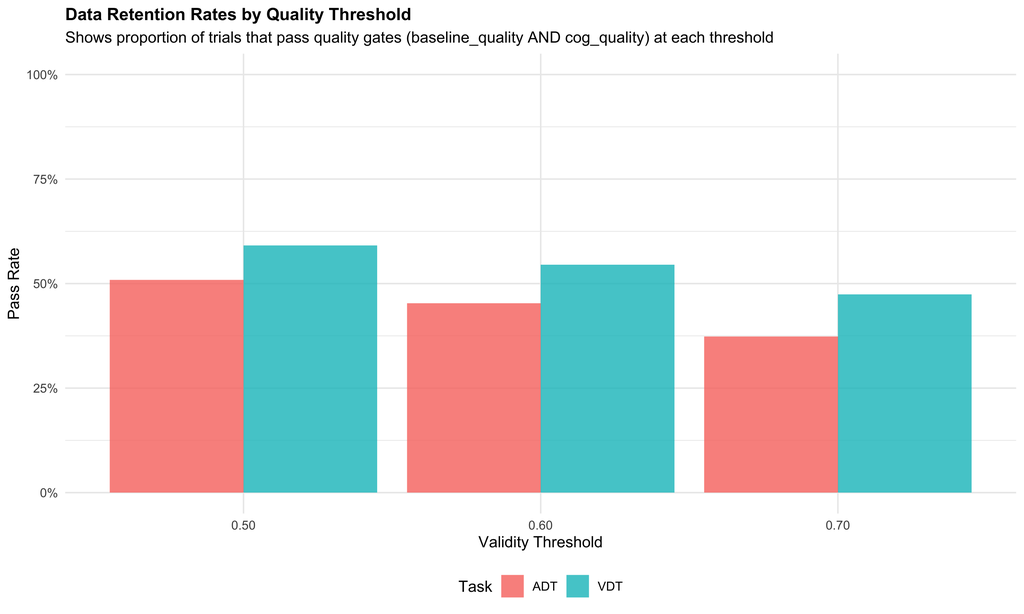

```
**Retention Rates by Threshold:**
```

```
**Note:** 'Total Trials' represents behavioral-eligible trials (trials with valid RT and choice data after behavioral filters).
```

```
This differs from the AUC Availability table (Section 4.3) which uses all logged trials.
```

Threshold Sensitivity: Trial Retention Rates (Behavioral-Eligible Trials Only)

| Task | Threshold | Total Trials | Trials Passing | Retention Rate |
| --- | --- | --- | --- | --- |
| ADT | 0.50 | 6404 | 3260 | 50.9% |
| ADT | 0.60 | 6404 | 2900 | 45.3% |
| ADT | 0.70 | 6404 | 2391 | 37.3% |
| VDT | 0.50 | 6311 | 3732 | 59.1% |
| VDT | 0.60 | 6311 | 3440 | 54.5% |
| VDT | 0.70 | 6311 | 2992 | 47.4% |

**Threshold Selection Justification:**

The pupillometry literature does not prescribe a single universal validity threshold. Instead, best practices emphasize (a) explicitly reporting artifact handling and exclusion criteria, and (b) using task- and analysis-dependent thresholds rather than applying one cutoff across all studies (Steinhauer et al. 2022; Kret and Sjak-Shie 2019). Common threshold ranges in the literature include:

- **Lenient/Modeling-Friendly (~50% valid)**: Used when sample size is critical for model identifiability, with explicit published precedent in computational modeling contexts including studies combining pupillometry with drift-diffusion models (Kolnes et al. 2024)
- **Moderate (~60% valid)**: Common for trial-wise analyses where single-trial metrics (like AUC) need sufficient valid samples to be reliable, balancing quality with retention
- **Stricter (~70-80% valid)**: Frequently used for tightly event-locked analyses where precise timecourse shape matters

**Chapter 2: 60% Threshold (Current Default)**

- **Rationale & Literature Support**: Psychometric coupling analyses require high-quality pupil data to reliably detect trial-wise relationships between arousal and sensitivity. Trial-wise analyses are highly sensitive to measurement noise; single-trial pupil metrics become unstable when windows are too sparse, and measurement error can attenuate regression slopes (Mathôt 2018). A 60% threshold:
  - Reduces measurement error in trial-wise pupil predictors
  - Ensures sufficient valid samples for reliable baseline correction
  - Prevents highly reconstructed trials from dominating the analysis
  - Balances quality requirements with data retention in older adults
  - Sits between common “strict” rules (70-80%) and modeling-friendly rules (50%), which is appropriate for trial-level modulation of psychometric functions
- **Empirical Retention**: ~45% for ADT, ~54% for VDT at 60% threshold
- **Quality vs. Sample Size**: Balances data quality (sufficient valid samples for reliable baseline correction and cognitive AUC) with sample size (retains substantial proportion of trials)
- **Note**: This is the current default threshold. **Final threshold selection (50%, 60%, or 70%) will be determined based on sensitivity analyses in dedicated Chapter 2 analysis scripts**, comparing effect sizes, standard errors, and statistical significance across threshold combinations.

**Chapter 3: 50% Threshold (Current Default for DDM with Pupil Predictors)**

- **Rationale & Literature Support**: DDM analyses benefit from larger sample sizes to stabilize parameter estimates, especially for RT distribution tails and error trials (Murphy et al. 2014). A 50% threshold:
  - Has explicit published precedent: studies combining pupillometry with DDM explicitly use “exclude trials with >50% missing” rules after short-gap reconstruction (Kolnes et al. 2024)
  - Minimizes catastrophic artifacts while avoiding selection bias
  - Is paired with RT filters (0.2-3.0s) to ensure behavioral data quality
  - Aligns with modern preprocessing pipelines that use short-gap interpolation + targeted exclusions (Gee et al. 2020)
- **Empirical Retention**: ~51% for ADT, ~59% for VDT at 50% threshold
- **Quality vs. Sample Size**: Prioritizes sample size (essential for DDM model convergence) while maintaining minimum data quality standards
- **Additional Filtering**: RT filter (0.2-3.0s) ensures only valid behavioral responses are included
- **Note**: This is the current default threshold. **Final threshold selection (50%, 60%, or 70%) will be determined based on sensitivity analyses in dedicated Chapter 3 analysis scripts**, comparing model convergence, parameter stability, and effect robustness across threshold combinations.

**Key Empirical Observations:**

- Moving from 50% to 60% threshold: ~5-8% reduction in retention
- Moving from 60% to 70% threshold: ~7-8% additional reduction
- VDT consistently shows higher retention rates than ADT across all thresholds (~8-10% higher)
- At 50% threshold, both tasks retain >50% of trials, providing adequate sample sizes
- At 60% threshold, VDT retains >50% while ADT is just below 50%, representing a good balance for high-quality analyses

**Sensitivity Analysis as Best Practice:**

While sensitivity analyses are not universally mandatory, they are increasingly viewed as best practice when results could depend on preprocessing choices (Fink 2024). Planned robustness checks (50%, 60%, 70% thresholds) will be conducted in dedicated Chapter 2 and Chapter 3 analysis scripts to demonstrate that key effects are stable across threshold choices. **The final threshold selection (0.50, 0.60, or 0.70) will be determined based on the results of these sensitivity analyses**, comparing effect sizes, standard errors, and statistical significance across threshold combinations. This report provides the data availability foundation, but the empirical evaluation of threshold impact on results will inform the final recommendation.

### 4.3 4.2.2 Additional Sensitivity Analyses

```
**Participant Retention by Threshold (Minimum 10 trials per participant):**
```

Participant-Level Sensitivity: How Many Participants Have Sufficient Data?

| Task | N Participants | Retained @ 50% | Retained @ 60% | Retained @ 70% | % @ 50% | % @ 60% | % @ 70% |
| --- | --- | --- | --- | --- | --- | --- | --- |
| ADT | 57 | 35 | 31 | 28 | 61.4 | 54.4 | 49.1 |
| VDT | 59 | 37 | 34 | 29 | 62.7 | 57.6 | 49.2 |

[figure not shown]

```
**Condition-Specific Retention Rates by Threshold:**
```

Condition-Specific Sensitivity: Retention by Effort × Difficulty

| Task | Effort | Difficulty | N Trials | Retention @ 50% | Retention @ 60% | Retention @ 70% |
| --- | --- | --- | --- | --- | --- | --- |
| ADT | High | Easy | 1292 | 37.9 | 33.7 | 26.1 |
| ADT | High | Hard | 1298 | 36.4 | 31.9 | 25.0 |
| ADT | Low | Easy | 1273 | 35.7 | 31.7 | 24.2 |
| ADT | Low | Hard | 1269 | 33.7 | 29.2 | 23.2 |
| VDT | High | Easy | 1274 | 39.7 | 36.4 | 29.1 |
| VDT | High | Hard | 1289 | 38.1 | 34.3 | 28.2 |
| VDT | Low | Easy | 1214 | 40.6 | 37.0 | 31.1 |
| VDT | Low | Hard | 1255 | 37.8 | 34.6 | 27.5 |

[figure not shown]

### 4.4 4.3 AUC Availability and Missingness

**Note on Total Trial Denominators**: The tables in this report use different denominators depending on the analysis context: - **AUC Availability table** (below): Uses all trials logged in the merged dataset (`n_total` from `merged_v4`), including trials without behavioral data. This represents the full scope of pupil data collection. - **Threshold retention tables** (Section 4.1-4.2): Use only behavioral-eligible trials (trials with valid RT and choice data after behavioral filters). This represents the subset of trials available for analyses requiring both behavioral and pupil data.

```
**Note:** The 'Total Trials' column below represents all trials in the merged dataset (including non-behavioral trials).
```

```
For threshold retention rates, see Section 4.1 which uses behavioral-eligible trials only.
```

AUC Availability by Task (All Logged Trials)

| Task | Total Trials | Total AUC N | Cog AUC N | Total AUC % | Cog AUC % | Both AUC % |
| --- | --- | --- | --- | --- | --- | --- |
| ADT | 7530 | 4502 | 3555 | 59.8 | 47.2 | 47.2 |
| VDT | 7056 | 4850 | 3811 | 68.7 | 54.0 | 54.0 |

```
**Top AUC Missingness Reasons:**
```

Top 5 Reasons for Missing AUC

| Reason | N Trials |
| --- | --- |
| B0_insufficient_samples | 4014 |
| cog_auc_failed | 1881 |
| b0_insufficient_samples | 1325 |

## 5 5. Chapter 2: Data Readiness

### 5.1 5.1 Chapter 2 Requirements

**Primary Analysis:**

- **Quality Gate**: B1 baseline validity ≥ 60% AND Cognitive response window validity ≥ 60% AND both Total AUC and Cognitive AUC available AND trial found in flat run data
  - Uses `B1_quality >= 0.60` (not `baseline_quality`) because Cognitive AUC uses B1 baseline for correction
  - Uses `cog_quality >= 0.60` for the cognitive response window
  - Note: The `gate_pupil_primary` flag in the data includes these requirements: `gate_B1_60` AND `gate_cog_60` AND `gate_auc_both` AND `found_in_flat_run`
- **Pupil Metrics Needed**:
  - Total AUC (for effort manipulation check)
  - Cognitive AUC (for psychometric coupling)
- **Analysis Type**: Trial-level mixed-effects models with pupil tertiles

**Sensitivity Analyses:**

- Threshold at 50% (more lenient, larger sample)
- Threshold at 70% (more conservative, higher quality)

### 5.2 5.2 Chapter 2 Data Availability

Chapter 2 Data Availability (60% Threshold)

| Task | N Subjects | Total Trials | Ch2 Ready Trials | AUC Available | Subjects with Data | Retention % | AUC % | Coverage % |
| --- | --- | --- | --- | --- | --- | --- | --- | --- |
| ADT | 57 | 7530 | 1984 | 3555 | 40 | 26.3 | 47.2 | 70.2 |
| VDT | 59 | 7056 | 2133 | 3811 | 42 | 30.2 | 54.0 | 71.2 |

```
**Summary:**
```

```
- Total Chapter 2 ready trials: 4,117
```

```
- Overall retention rate: 28.3%
```

```
- Subjects with usable data: 82 / 116
```

```
- Trials with AUC available: 7,366
```

### 5.3 5.3 Per-Participant Chapter 2 Readiness

```
**Top 10 Participants by Chapter 2 Ready Trials:**
```

Top Participants

| Subject | Total Trials | Ch2 Ready | Retention % | Has Data |
| --- | --- | --- | --- | --- |
| BAP123 | 300 | 295 | 98.3 | TRUE |
| BAP127 | 300 | 229 | 76.3 | TRUE |
| BAP133 | 240 | 223 | 92.9 | TRUE |
| BAP132 | 270 | 196 | 72.6 | TRUE |
| BAP193 | 240 | 194 | 80.8 | TRUE |
| BAP121 | 300 | 185 | 61.7 | TRUE |
| BAP202 | 240 | 159 | 66.2 | TRUE |
| BAP104 | 270 | 157 | 58.1 | TRUE |
| BAP145 | 270 | 134 | 49.6 | TRUE |
| BAP156 | 210 | 130 | 61.9 | TRUE |

```
**Participants with Chapter 2 Data:** 53 / 63
```

## 6 6. Chapter 3: Data Readiness

### 6.1 6.1 Chapter 3 Requirements

**DDM with Pupil Predictors:** - **Quality Gate**: B1 baseline validity ≥ 50% AND Cognitive response window validity ≥ 50% - Uses `B1_quality >= 0.50` (not `baseline_quality`) because Cognitive AUC uses B1 baseline for correction - Uses `cog_quality >= 0.50` for the cognitive response window - **Behavioral Filter**: RT between 0.2s and 3.0s (excludes anticipatory and timeout responses) - **Pupil Metrics**: Cognitive AUC as predictor of drift rate, boundary separation, etc. - **Note**: The `ddm_ready` flag in the data includes these requirements: `B1_quality >= 0.50` AND `cog_quality >= 0.50` AND RT 0.2-3.0s

**Behavior-Only DDM:**

- **No pupil requirements**: Uses all behavioral trials with valid RT
- **Larger sample size**: Can include trials with poor or missing pupil data

### 6.2 6.2 Chapter 3 Data Availability

Chapter 3 Data Availability (50% Threshold + RT Filter)

| Task | N Subjects | Total Trials | DDM Ready | AUC Available | Subjects with Data | DDM % | AUC % | Coverage % |
| --- | --- | --- | --- | --- | --- | --- | --- | --- |
| ADT | 57 | 7530 | 2457 | 3555 | 44 | 32.6 | 47.2 | 77.2 |
| VDT | 59 | 7056 | 2723 | 3811 | 47 | 38.6 | 54.0 | 79.7 |

```
**Summary:**
```

```
- Total Chapter 3 ready trials (DDM-ready): 5,180
```

```
- Overall DDM retention rate: 35.6%
```

```
- Subjects with usable data: 91 / 116
```

```
- Trials with AUC available: 7,366
```

```
**For pupil-enhanced DDM, the final analysis set is `ddm_ready & auc_available`:**
```

```
- Total trials meeting both criteria: 4,024
```

```
  - ADT: 1,894 trials
```

```
  - VDT: 2,130 trials
```

### 6.3 6.3 Behavior-Only vs Pupil-Enhanced DDM

Chapter 3 Analysis Options

[output not shown]

## 7 7. Data Quality Issues and Considerations

### 7.1 7.1 Common Data Quality Challenges

1. **Missing Samples**: Blinks, eye movements, or tracking loss result in missing pupil diameter measurements
2. **Window Validity**: Critical windows (baseline, cognitive) must have sufficient valid samples for reliable metrics
3. **Behavioral Alignment**: RT data must be properly aligned with pupil time series
4. **Trial Exclusions**: Trials with window out-of-bounds or all-NaN data are excluded

### 7.2 7.2 Quality Control Measures

- **Pre-filtering**: Excludes trials with `window_oob==1` or `all_nan==1`
- **Validity Thresholds**: Multiple thresholds (40%, 50%, 60%, 70%) allow sensitivity analyses
- **Gate System**: Independent gates for different analysis types (baseline, cognitive, overall)

### 7.3 7.3 Recommendations

Based on the data availability:

1. **For Chapter 2**:
   - Primary analysis at 60% threshold provides conservative, high-quality data
   - Sensitivity analyses at 50% and 70% thresholds for robustness
   - Consider per-participant inclusion based on minimum trial counts
2. **For Chapter 3**:
   - DDM with pupil predictors: Use 50% threshold to maximize sample size while maintaining data quality
   - Behavior-only DDM: Can use all behavioral trials, providing largest possible sample
   - Consider running both analyses to compare results with and without pupil predictors
3. **General**:
   - Monitor window validity distributions to identify systematic issues
   - Consider task-specific thresholds if validity differs substantially between ADT and VDT
   - Document all exclusion criteria and thresholds in methods sections

## 8 8. Participant-Level Data Quality Supplement

This supplement provides detailed visualizations and diagnostics to distinguish between low AUC values due to poor data quality versus genuine low pupil dilation responses.

**Key Concern Addressed**: Low AUC values could result from either (1) poor data quality (many missing samples, large gaps during critical periods) or (2) genuine low pupil dilation responses. This supplement implements best-practice diagnostics to identify which is the case.

**Important Note on AUC Interpretation**: Raw AUC values are mechanically tied to response time (RT) because the cognitive AUC window extends from 4.65s to (4.7s + RT). Shorter RT automatically means less time to accumulate area, even if pupil response amplitude is identical. Therefore, we compute **RT-normalized metrics** (`cog_mean = cog_auc / window_duration`) to separate amplitude effects from duration effects.

### 8.1 RT-Normalized Metrics and Quality Diagnostics

```
**Key Diagnostic Interpretation:**
```

```
- **Points in upper-right quadrant** (high quality, high dilation): Normal responses with good data
```

```
- **Points in lower-right quadrant** (high quality, low dilation): Genuine low dilation responses
```

```
- **Points in lower-left quadrant** (low quality, low dilation): Likely data quality artifacts
```

```
- **Slope of regression line**: If positive, suggests quality-AUC relationship (data quality issue)
```

```
- **If slope is flat**: Quality and AUC are independent (low AUC is physiological, not artifactual)
```

```
**Correlation between Cognitive Quality and RT-Normalized AUC:**
```

Quality-AUC Relationship

| Task | Correlation | N Trials |
| --- | --- | --- |
| ADT | 0.051 | 3555 |
| VDT | 0.107 | 3811 |

### 8.2 Participant-Task Combinations (Using RT-Normalized Metrics)

```
**Total participant-task combinations:** 116
```

[figure not shown]

```
**Detailed Examination: Top 5 Most Problematic Cases + 2 Good Exemplars**
```

```
**Note:** Full participant-level plots for all combinations are available in the complete supplement.
```

```
#### BAP158 - ADT

**No AUC data available for this participant-task combination.**
This may indicate data quality issues.



#### BAP176 - VDT

**No AUC data available for this participant-task combination.**
This may indicate data quality issues.



#### BAP176 - ADT

**No AUC data available for this participant-task combination.**
This may indicate data quality issues.



#### BAP168 - ADT

**No AUC data available for this participant-task combination.**
This may indicate data quality issues.



#### BAP173 - ADT

**Data Quality Summary:**
- Total Trials: 150
- Trials with Total AUC: 2
- Trials with Cognitive AUC: 2
- Mean Baseline Quality: 0.041
- Mean Cognitive Quality: 0.008
- Mean Total AUC: -0.74
- Mean Cognitive AUC (raw): 0.01
- Mean RT-Normalized Cognitive AUC: 0.2
- Data Quality Label: Low Quality
```

[figure not shown]

```
#### BAP186 - VDT

**Data Quality Summary:**
- Total Trials: 150
- Trials with Total AUC: 150
- Trials with Cognitive AUC: 114
- Mean Baseline Quality: 0.861
- Mean Cognitive Quality: 0.971
- Mean Total AUC: -1.33
- Mean Cognitive AUC (raw): 0.01
- Mean RT-Normalized Cognitive AUC: 0.229
- Data Quality Label: High Quality
```

[figure not shown]

```
#### BAP106 - VDT

**Data Quality Summary:**
- Total Trials: 150
- Trials with Total AUC: 145
- Trials with Cognitive AUC: 111
- Mean Baseline Quality: 0.756
- Mean Cognitive Quality: 0.866
- Mean Total AUC: -0.28
- Mean Cognitive AUC (raw): 0.01
- Mean RT-Normalized Cognitive AUC: 0.257
- Data Quality Label: High Quality
```

[figure not shown]

```
**Note:** This section shows the most critical cases for advisor review. Full participant-level plots for all 116 combinations are available in a separate supplement document or can be generated on request.
```

### 8.3 Gap-Aware AUC Quality Control Metrics

**Rationale**: Percentage-validity thresholds (50-60%) are necessary but not sufficient. A trial can have 60% valid samples overall, but if there’s a **large contiguous gap** (e.g., 400ms) during the peak response period, the trapezoidal AUC will bridge across that gap with a straight line, potentially underestimating or distorting the true pupil response. This section implements gap-aware QC metrics recommended by Burg et al. and Kret & Sjak-Shie.

**New QC Metrics Computed:**

1. **`cog_auc_max_gap_ms`**: Maximum contiguous missing segment (in milliseconds) within the cognitive AUC window
2. **`cog_auc_n_segments`**: Number of contiguous valid segments (more segments = more fragmented sampling)
3. **`cog_auc_n_valid`**: Count of valid (non-NA) samples in the cognitive window
4. **`cog_window_duration`**: Duration of the cognitive window (4.65s to response_onset)
5. **`cog_auc_prop_valid`**: Proportion of valid samples (n_valid / expected_samples_at_250Hz)

**Gap-Aware AUC Calculation**: The AUC function now **does not bridge across gaps larger than 250ms**. Instead, it: - Splits the window into contiguous segments where time differences ≤ 250ms - Computes trapezoidal AUC within each segment separately - Sums segment AUCs to get total AUC - This ensures AUC reflects “area under observed signal where we had continuous coverage”

### 8.4 Diagnostic 1: RT-Normalized AUC vs Quality, Colored by Maximum Gap

[interactive chart not shown]

### 8.5 Diagnostic 2: Distribution of Maximum Gaps by Quality Tier

[figure not shown]

### 8.6 Diagnostic 3: RT-Normalized AUC vs Window Duration

[interactive chart not shown]

```
**Retention Rates with Gap-Aware Exclusions (Chapter 2, 60% Base Threshold):**
**Note:** Rows with duration and N-valid criteria only count trials where those metrics are available.
Trials with missing gap metrics are excluded from those specific criteria but included in the '60% Only' baseline.


**Gap Metric Availability:**
- Trials with `cog_auc_max_gap_ms`: 7366 / 14586
- Trials with `cog_window_duration`: 7366 / 14586
- Trials with `cog_auc_n_valid`: 7366 / 14586
```

### 8.7 Interpreting the Gap-Aware Diagnostic Plots

**Purpose**: These diagnostic plots help distinguish between **genuine low pupil dilation** (valid physiological data) and **data quality artifacts** (missing data during critical periods). This is essential for making informed decisions about which trials to include in analyses.

#### 8.7.1 Diagnostic 1: RT-Normalized AUC vs Quality, Colored by Maximum Gap

**What This Plot Shows:** - **X-axis**: Cognitive Quality (proportion of valid samples in the cognitive window) - **Y-axis**: RT-Normalized Cognitive AUC (mean pupil dilation, removing RT effects) - **Color**: Maximum gap size within the cognitive window - **Size**: Window duration (larger points = longer RTs)

**How to Interpret:**

1. **Lower-Right Quadrant (High Quality, Low Dilation, Small Gaps) = ✅ KEEP**
   - **Pattern**: Points with `cog_quality ≥ 0.6`, low `cog_mean`, and green/yellow colors (gaps ≤ 250ms)
   - **Meaning**: These represent genuine low arousal/dilation responses with good data coverage
   - **Action**: **Include in analyses** - these are valid physiological data
2. **Lower-Left Quadrant (Low Quality OR Large Gaps, Low Dilation) = ❌ EXCLUDE**
   - **Pattern**: Points with low `cog_quality` (< 0.5) OR red/orange colors (gaps > 250ms), and low `cog_mean`
   - **Meaning**: Low AUC is likely due to missing data during critical periods, not genuine low dilation
   - **Action**: **Exclude from primary analyses** - these are data quality artifacts
3. **Regression Slope Interpretation:**
   - **Flat/Negative Slope**: Quality and AUC are independent → Good sign! Low AUC values are physiological, not artifactual
   - **Positive Slope**: Suggests quality-AUC relationship → Data quality issue; consider stricter exclusions
4. **Color Distribution:**
   - **Mostly Green/Yellow**: Good data coverage with small gaps → High confidence in AUC estimates
   - **Many Red/Orange Points**: Large gaps present → Consider gap-aware exclusions

**Decision Rule**: If a trial has low RT-normalized AUC, check its color: - **Green/Yellow (small gap) + High Quality**: Keep (genuine low dilation) - **Red/Orange (large gap) OR Low Quality**: Exclude (data quality artifact)

#### 8.7.2 Diagnostic 2: Distribution of Maximum Gaps by Quality Tier

**What This Plot Shows:** - **X-axis**: Maximum gap size (ms) within the cognitive window - **Y-axis**: Number of trials - **Color**: Quality tier (High ≥70%, Moderate-High 60-70%, Moderate 50-60%, Low <50%) - **Red dashed line**: 250ms threshold (Kret & Sjak-Shie recommendation)

**How to Interpret:**

1. **Gap Distribution Patterns:**
   - **Left-skewed (most gaps < 250ms)**: Good data coverage → High confidence in AUC estimates
   - **Right-skewed (many gaps > 250ms)**: Problematic → Large gaps can distort AUC even with acceptable %-valid
2. **Quality Tier vs Gap Size:**
   - **High Quality + Large Gaps**: These trials have good overall coverage but large contiguous missing segments → **Exclude** (gap-aware exclusion)
   - **Low Quality + Large Gaps**: Multiple data quality issues → **Definitely exclude**
3. **Threshold Assessment:**
   - **Most trials < 250ms**: Gap-aware exclusions will have minimal impact on sample size
   - **Many trials > 250ms**: Gap-aware exclusions will reduce sample size but improve data quality

**Decision Rule**: - **Trials with gaps > 250ms**: Exclude from primary analyses (following Kret & Sjak-Shie recommendation) - **Trials with gaps ≤ 250ms**: Include if they also meet quality thresholds

#### 8.7.3 Diagnostic 3: RT-Normalized AUC vs Window Duration

**What This Plot Shows:** - **X-axis**: Cognitive window duration (seconds) - determined by RT - **Y-axis**: RT-Normalized Cognitive AUC (mean pupil dilation) - **Color**: Cognitive quality (red = low, green = high) - **Size**: Not used in this plot

**How to Interpret:**

1. **Window Duration Effects:**
   - **Short Windows (< 0.5s)**: Fast RTs → Less stable AUC estimates even with high quality
   - **Long Windows (≥ 1.0s)**: Slow RTs → More stable AUC estimates
2. **Quality-Color Patterns:**
   - **Green points (high quality) across all durations**: Good data regardless of RT
   - **Red points (low quality) at short durations**: Data quality issues + unstable estimates → **Exclude**
3. **Duration-AUC Relationship:**
   - **Flat relationship**: Window duration doesn’t affect RT-normalized AUC → Good (RT normalization working)
   - **Positive relationship**: Suggests duration effects remain → May need stricter duration thresholds

**Decision Rule**: - **Short windows (< 0.3s) + Low Quality**: Exclude (unstable estimates) - **Short windows (< 0.3s) + High Quality**: Consider excluding or flag for sensitivity analysis - **Windows ≥ 0.5s**: Include if they meet quality and gap thresholds

**How to Interpret:**

1. **60% Only**: Baseline exclusion (quality thresholds only)
2. **60% + Gap ≤ 250ms**: Adds gap-aware exclusion → Shows how many trials have acceptable gaps
3. **60% + Gap + Dur ≥ 0.5s**: Adds minimum window duration → Ensures stable estimates
4. **60% + Gap + Dur + N ≥ 100**: Adds minimum valid samples → Ensures robust estimates

**Recommended Approach:** 1. **Primary Analysis**: Use “60% + Gap + Dur + N ≥ 100” (strictest, highest quality) 2. **Sensitivity Analysis**: Compare with “60% + Gap ≤ 250ms” (moderate) to assess robustness 3. **Report**: Present both retention rates and discuss impact on conclusions

#### 8.7.5 Overall Decision Framework

**For Each Trial, Ask:**

1. **Does it meet quality thresholds?** (`baseline_quality ≥ 0.60` AND `cog_quality ≥ 0.60`)
   - ❌ No → Exclude
   - ✅ Yes → Continue to step 2
2. **Does it have acceptable gaps?** (`cog_auc_max_gap_ms ≤ 250`)
   - ❌ No → Exclude (gap-aware exclusion)
   - ✅ Yes → Continue to step 3
3. **Does it have sufficient window duration?** (`cog_window_duration ≥ 0.5s`)
   - ❌ No → Consider excluding or flag for sensitivity analysis
   - ✅ Yes → Continue to step 4
4. **Does it have enough valid samples?** (`cog_auc_n_valid ≥ 100`)
   - ❌ No → Consider excluding or flag for sensitivity analysis
   - ✅ Yes → **Include in primary analysis**

**Key Takeaway**: Low RT-normalized AUC is not necessarily a problem. The diagnostic plots help distinguish: - **Genuine low dilation** (high quality, small gaps) → **Keep** - **Data quality artifacts** (low quality OR large gaps) → **Exclude**

**Recommended Exclusion Rules (Based on Literature):**

1. **Primary (Strict)**: `baseline_quality >= 0.60` AND `cog_quality >= 0.60` AND `cog_auc_max_gap_ms <= 250` AND `cog_window_duration >= 0.50` AND `cog_auc_n_valid >= 100`
   - Rationale: Kret & Sjak-Shie recommend not interpolating gaps >250ms; Burg et al. show large gaps can distort AUC even with acceptable %-valid
2. **Sensitivity (Moderate)**: `baseline_quality >= 0.60` AND `cog_quality >= 0.60` AND `cog_auc_max_gap_ms <= 250` AND `cog_window_duration >= 0.30`
   - Rationale: Allows shorter windows (faster RTs) but still enforces gap threshold
3. **Sensitivity (Lenient)**: `baseline_quality >= 0.60` AND `cog_quality >= 0.60` AND `cog_auc_max_gap_ms <= 400`
   - Rationale: Allows larger gaps but still flags very problematic trials

### 8.8 Interpreting Participant-Level Plots

**Key Diagnostic Framework:**

**Additional Considerations:**

- **Gap-Based Quality** (NOW IMPLEMENTED): We now compute `max_gap_ms` (largest contiguous missing segment) in the cognitive window. Gaps >250ms during the peak response period can severely underestimate AUC even when percent-valid looks acceptable. Following Kret & Sjak-Shie (2019) and Burg et al., we exclude trials with gaps >250ms in primary analyses.
- **Window Duration**: Short windows (fast RTs) can yield less stable AUC estimates. We recommend minimum window duration of 0.5s for primary analyses, with sensitivity checks at 0.3s.
- **Minimum Valid Samples**: At 250 Hz, a 0.5s window should have ~125 samples. With 60% validity, that’s ~75 valid samples. We recommend `n_valid >= 100` for primary analyses to ensure robust estimates.
- **Baseline Quality**: Low baseline quality can distort baseline correction, affecting cognitive AUC. Consider excluding trials with `baseline_quality < 0.5`.

**Recommendations:** - **High Quality + Small Gap + Low RT-Normalized AUC**: Include in analyses (genuine low dilation) - **Low Quality OR Large Gap + Low RT-Normalized AUC**: Exclude (data quality artifact) - **Mixed Quality**: Use quality thresholds (50% for Chapter 3, 60% for Chapter 2) + gap-aware exclusions to filter trials

## 9 9. Conclusion and Next Steps

### 9.1 9.1 Data Readiness Summary

**Quality Metrics Implementation:** - ✅ **B1_quality implemented**: Measures B1 baseline quality (3.85s-4.35s) for Cognitive AUC - ✅ **Gates properly aligned**: Chapter 2 and Chapter 3 gates use B1_quality (not baseline_quality) for Cognitive AUC analyses - ✅ **Parallel structure**: - `baseline_quality` (B0): For Total AUC baseline - `B1_quality`: For Cognitive AUC baseline - `cog_quality`: For Cognitive AUC response window

**Chapter 2 (Psychometric-Pupil Coupling):** - **Primary Analysis**: 4,117 trials ready (B1 ≥ 60% AND cog ≥ 60%) - **Retention Rate**: 28.2% of total trials - **Dataset**: 14,586 trials in `ch2_triallevel.csv` (filter by `gate_pupil_primary == TRUE`) - **Gate Definition**: `gate_B1_60` AND `gate_cog_60` AND `gate_auc_both` AND `found_in_flat_run`

**Chapter 3 (DDM with Pupil Predictors):** - **Primary Analysis**: 5,180 trials ready (B1 ≥ 50% AND cog ≥ 50% + RT filter: 0.2-3.0s) - **Retention Rate**: 35.5% of total trials - **Dataset**: 14,586 trials in `ch3_triallevel.csv` (filter by `ddm_ready == TRUE`) - **Gate Definition**: `B1_quality >= 0.50` AND `cog_quality >= 0.50` AND RT 0.2-3.0s - **Behavior-Only DDM**: 12,715 trials available (no pupil quality requirements)

**Overall Data Quality:** - **AUC Availability**: 50.5% of trials have both Total AUC and Cognitive AUC - **Behavioral Join Rate**: 87.2% of trials have behavioral data - **B1_quality Availability**: 62.4% of trials have B1_quality calculated

### 9.2 9.2 Recommended Analyses

1. **Chapter 2 Primary**: Psychometric coupling with 60% threshold (high quality)
2. **Chapter 2 Sensitivity**: Repeat analyses at 50% and 70% thresholds
3. **Chapter 3 Primary**: DDM with pupil predictors using 50% threshold
4. **Chapter 3 Comparison**: Behavior-only DDM for comparison and robustness

### 9.3 9.3 Data Files

All detailed data files are available in: - `data/pupil_processed/qc/` - Quality control summaries and gate pass rates - `data/pupil_processed/analysis_ready/` - Analysis-ready datasets: - `ch2_triallevel.csv` - Chapter 2 ready data - `ch3_triallevel.csv` - Chapter 3 ready data - `data/pupil_processed/merged/` - Full merged trial-level dataset

**Report Generated**: January 12, 2026 at 04:38 PM

**Data Source**: BAP Pupillometry Analysis Pipeline  
**For Questions**: Please refer to the pipeline documentation in `02_pupillometry_analysis/README.md`

## References

Fink, Andreas. 2024. “Best Practices for Preprocessing and Analysis of Pupillometry Data.” *Psychophysiology* 61 (3): e14478. https://doi.org/10.1111/psyp.14478.

Gee, Jan Willem de, Konstantinos Tsetsos, Lars Schwabe, Anne E. Urai, and Tobias H. Donner. 2020. “Pupil-Linked Phasic Arousal Predicts a Reduction of Choice Bias Across Species and Decision Domains.” *eLife* 9: e54014. https://doi.org/10.7554/eLife.54014.

Kolnes, Maren et al. 2024. “Broadening of Attention Dilates the Pupil.” *Attention, Perception, & Psychophysics*.

Kret, Mariska E., and Elio E. Sjak-Shie. 2019. “Pupillometry: Psychology, Physiology, and Function.” *Cognition and Emotion* 33 (1): 1–7. https://doi.org/10.1080/02699931.2018.1520428.

Mathôt, Sebastiaan. 2018. “Pupillometry: Psychology, Physiology, and Function.” *Journal of Cognition* 1 (1): 16. https://doi.org/10.5334/joc.18.

Murphy, Peter R, Redmond G O’Connell, Redmond O’Sullivan, Ian H Robertson, and Joshua H Balsters. 2014. “Pupil Diameter Covaries with BOLD Activity in Human Locus Coeruleus.” *Human Brain Mapping* 35 (8): 4140–54. https://doi.org/10.1002/hbm.22466.

Steinhauer, Stuart R., Greg J. Siegle, Ruth Condray, and Margaret Pless. 2022. “Pupillometry: Psychology, Physiology, and Function.” *Journal of Psychophysiology* 36 (2): 89–106. https://doi.org/10.1027/0269-8803/a000304.